# AP-4209 ESIEE-Paris: 2024 - 2025

Fouille de données avec R pour la data science et l’intelligence artificielle

III.TD 3 : Partie II - ANALYSE FACTORIELLE DISCRIMINANTE

Badr TAJINI – ESIEE Paris  
Source : Bertrand Roudier – ESIEE Paris

### 1. Introduction

Ce TD a pour objectif de réaliser une analyse factorielle discriminante nous permettant :

- à l’aide d’une diminution de dimentionnalité, de visualiser les données dans le plan des axes facoriels (cf.cours)
- d’effectuer, pour chaque axe, une inférence statistique qui permet de tester la discrimination des différentes classes projetées.

Au total, l’AFD est analogue à une MANOVA, nous permettant de réaliser, de manière concomitante, une visualisation des données.

Pour y parvenir, nous utiliserons le jeu de données *VIN_QUALITE.txt*

### 2. Prés-Requis

- Nous chargeons le fichier *VIN_QUALITE.txt*
- Nous utilisons la fonction que nous avons développée lors du précédant TP pour calculer les sommes des carrés totaux, inter et intra.

```r
# Installation/Chargement des paquets nécessaires
if(!require(kableExtra)) install.packages("kableExtra")
library(kableExtra)
```

```r
# Chargement du jeu de données des vins
df <- read.table("VIN_QUALITE.txt", header = TRUE)

# Aperçu de la structure des données
str(df)
```

```
## 'data.frame':    34 obs. of  5 variables:
##  $ TP     : int  3064 3000 3155 3085 3245 3267 3080 2974 3038 3318 ...
##  $ Soleil : int  1201 1053 1133 970 1258 1386 966 1189 1103 1310 ...
##  $ Chaleur: int  10 11 19 4 36 35 13 12 14 29 ...
##  $ Pluie  : int  361 338 393 467 294 225 417 488 677 427 ...
##  $ Qualite: chr  "moyen" "mauvais" "moyen" "mauvais" ...
```

Rappel de la fonction MANOVA du TD précédent : Cette fonction calcule les matrices d’inertie (SS Totale, SS Intra, SS Inter) nécessaires pour l’AFD.

```r
# Fonction MANOVA développée au TD précédent
MANOVA <- function(X, Y) {
  X <- as.matrix(X)
  Y <- as.factor(Y)
  N <- nrow(X)
  P <- ncol(X)
  K <- nlevels(Y)

  # Calcul des moyennes
  G <- colMeans(X)
  XK <- split(as.data.frame(X), Y)
  GK <- lapply(XK, colMeans)

  # Inertie Totale (SST)
  G_mat <- matrix(rep(G, N), nrow = N, byrow = TRUE)
  Diff_Tot <- X - G_mat
  SS_tot <- t(Diff_Tot) %*% Diff_Tot

  # Inertie Intra (SSW)
  SS_intra <- matrix(0, nrow = P, ncol = P)
  for (i in 1:K) {
    X_k <- as.matrix(XK[[i]])
    n_k <- nrow(X_k)
    G_k_mat <- matrix(rep(GK[[i]], n_k), nrow = n_k, byrow = TRUE)
    Diff_k <- X_k - G_k_mat
    SS_intra <- SS_intra + t(Diff_k) %*% Diff_k
  }

  # Inertie Inter (SSB)
  SS_inter <- SS_tot - SS_intra

  # Inférence Statistique (Wilks Lambda)
  Lambda <- det(SS_intra) / det(SS_tot)
  stat_test <- -(N - 1 - (P + K)/2) * log(Lambda)
  ddl <- P * (K - 1)
  p_value <- 1 - pchisq(stat_test, df = ddl)

  return(list(
    SS_tot = SS_tot,
    SS_Intra = SS_intra,
    SS_Inter = SS_inter,
    Gk = GK,
    G = G,
    Lambda = Lambda,
    Probability = p_value
  ))
}
```

```r
# Préparation des données pour l'analyse
# Les 4 premières colonnes sont les variables quantitatives (X)
# La colonne 'Qualite' est la variable qualitative à prédire (Y)
X <- df[, 1:4]
Y <- as.factor(df$Qualite)

# Exécution de la MANOVA pour obtenir les matrices d'inertie
res_manova <- MANOVA(X, Y)
print("Calcul effectué !")
```

```
## [1] "Calcul effectué !"
```

Les résultats sont les suivants:

- La somme des carrés totaux : *SS <sub>Tot</sub>*

```r
# Affichage de la matrice d'Inertie Totale
res_manova$SS_tot
```

```
##                 TP     Soleil    Chaleur      Pluie
## TP       657789.53  420250.29  40372.294 -174435.24
## Soleil   420250.29  529101.44  27056.941 -180803.85
## Chaleur   40372.29   27056.94   3310.941  -12119.35
## Pluie   -174435.24 -180803.85 -12119.353  275690.38
```

- La somme des carrés intra : *SS <sub>Intra</sub>*

```r
# Affichage de la matrice d'Inertie Intra-classe (W)
res_manova$SS_Intra
```

```
##                TP    Soleil   Chaleur      Pluie
## TP      237722.12  58284.70 14300.939  13337.303
## Soleil   58284.70 202192.37  5245.220  -4898.030
## Chaleur  14300.94   5245.22  1664.371  -1079.515
## Pluie    13337.30  -4898.03 -1079.515 178499.212
```

- La somme des carrés inter : *SS <sub>Inter</sub>*

```r
# Affichage de la matrice d'Inertie Inter-classe (B)
res_manova$SS_Inter
```

```
##                 TP     Soleil   Chaleur      Pluie
## TP       420067.41  361965.60  26071.35 -187772.54
## Soleil   361965.60  326909.07  21811.72 -175905.82
## Chaleur   26071.35   21811.72   1646.57  -11039.84
## Pluie   -187772.54 -175905.82 -11039.84   97191.17
```

### 3. Analyse Factorielle Discriminante

#### 3.1 Rappels

Comme nous l’avons vu en cours, l’analyse factorielle discriminante consiste à trouver une succession d’axes factoriels, tous orthogonaux entre eux et qui maximisent les projections des distances entre les groupes (cf. schéma suivant pour rappel)

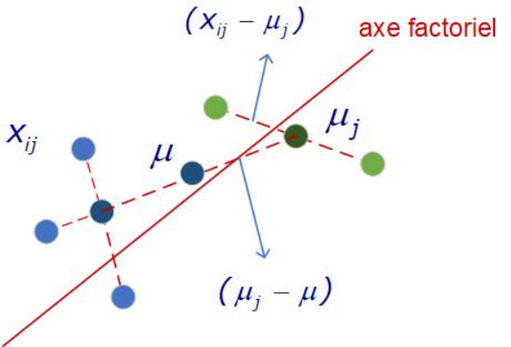

Maximiser les distances entre les groupes revient à maximiser les projections suivantes :

- ${P_1} = {\max _u}\left( {\frac{{{u^t}Bu}}{{{u^t}Wu}}} \right)$ (école Anglo saxonne)

ou bien

Fort heureusement, les deux méthodes conduisent aux mêmes résultats. Cependant, les approches sont légèrement différentes.

- La méthode anglo-saxonne à un raisonnement analogue à la construction du test d’analyse de variance ou l’on teste le rapport Signal / Bruit (cf. cours page 11). Dans ce cadre, la projection des distances inter groupes est pondérée par les distances intra-groupes
- La méthode française privilégie quant à elle la corrélation canonique c.a.d la part de variation liés au traitement (cf. cours page 11). Dans ce cadre, la projection des distances inter groupes est pondérée par la variation totale

Vous réaliserez une fonction permettant de réaliser une AFD selon la projection *P<sub>1</sub>* (méthode anglo saxonne). Pour y parvenir, nous allons décrire les différentes étapes avec les résultats intermédiaires.

#### 3.2 Diagonalisation

- Nous calculons la matrice du ratio :

  $\frac{B}{W} = \frac{{S{S_{{\rm{inter}}}}}}{{S{S_{{\rm{intra}}}}}} = B \times {W^{ - 1}} = S{S_{{\rm{inter}}}} \times SS_{{\rm{intra}}}^{ - 1}$

Attention la fraction ici correspond à une *division matricielle* et non à une division élément par élément !

Le résultat est le suivant :

```r
# Calcul du produit matriciel B * Inverse(W)
# La fonction solve(A) calcule l'inverse de la matrice A
Mat_Ratio <- res_manova$SS_Inter %*% solve(res_manova$SS_Intra)
Mat_Ratio
```

```
##                 TP      Soleil    Chaleur       Pluie
## TP       1.7809364  1.37080650 -4.7209142 -1.17595742
## Soleil   1.5908204  1.26842478 -5.2756786 -1.10143605
## Chaleur  0.1080854  0.08128061 -0.2404111 -0.06914774
## Pluie   -0.8489187 -0.69472817  3.2452899  0.60848446
```

Nous calculons maintenant les vecteurs directeurs *u* des axes factoriels et leur coefficient. De manière analogue à l’ACP, la maximisation de
$${P_1} = {\max _u}\left(
{\frac{{{u^t}Bu}}{{{u^t}Wu}}} \right)$$
revient à diagonaliser la matrice $S{S_{{\rm{inter}}}} \times SS_{{\rm{intra}}}^{ - 1}$. Les vecteurs propres correspondent alors aux vecteurs directeurs des axes factoriels. Ces derniers devront être cependant normalisés.
Comme en ACP, les valeurs propres correspondent à la part de dispersion expliquée par chaque axe.

- La diagonalisation est réalisée à l’aide de la fonction *eigen()*
- *remarque importante* : Les algorithmes utilisés peuvent conduire à des matrices de vecteurs propres dont les éléments sont des complexes. *On ne retiendra donc que les parties réels en éliminant les parties complexes* (utiliser la fonction *Re*)

##### 3.2.1 Vecteurs directeurs

- Matrice des vecteurs propres *U*

```r
# Diagonalisation de la matrice
res_eigen <- eigen(Mat_Ratio)

# On ne garde que la partie réelle
U <- Re(res_eigen$vectors)

print("Aperçu des vecteurs propres (U) :")
```

```
## [1] "Aperçu des vecteurs propres (U) :"
```

```r
print(head(U))
```

```
##             [,1]        [,2]          [,3]        [,4]
## [1,] -0.70217123 -0.82219379 -5.503074e-01  0.14551893
## [2,] -0.62706262  0.22861004  8.342436e-01  0.47836292
## [3,] -0.04262151 -0.09183439  3.463226e-02 -0.02185531
## [4,]  0.33456157 -0.51312890  2.397299e-05  0.86574564
```

Contrairement à l’ACP où nous diagonalisons une matrice symétrique (matrice des variances covariances ou de corrélation), la matrice du ratio *B/W* n’est pas symétrique ce qui conduit à des résultats non exploitables car non normées. Pour y parvenir, nous normalisons la matrice des vecteurs propres :

- Soit *U* la matrice des vecteurs propres: nous calculons *U <sub>Norm</sub>* tel que :

${U_{Norm}} = \frac{U}{{\sqrt {diag({U^t} \times W \times U)} }}$

- la matrice de normalisation (dénominateur) est la suivante :

```r
# Récupération de la matrice Intra (W)
W <- res_manova$SS_Intra

# Calcul du facteur de normalisation : racine de la diagonale de (U' * W * U)
denom <- sqrt(diag(t(U) %*% W %*% U))
denom
```

```
## [1] 514.7580 458.9237 398.6893 438.5759
```

- La matrice des vecteurs propres normalisées *Un* est:

```r
# Division de chaque vecteur propre par son facteur de normalisation
U_Norm <- scale(U, center = FALSE, scale = denom)

print("Aperçu des vecteurs propres normalisés :")
```

```
## [1] "Aperçu des vecteurs propres normalisés :"
```

```r
print(head(U_Norm))
```

```
##               [,1]          [,2]          [,3]          [,4]
## [1,] -1.364080e-03 -0.0017915698 -1.380291e-03  3.317987e-04
## [2,] -1.218170e-03  0.0004981439  2.092465e-03  1.090719e-03
## [3,] -8.279911e-05 -0.0002001082  8.686528e-05 -4.983245e-05
## [4,]  6.499395e-04 -0.0011181138  6.012951e-08  1.973993e-03
```

##### 3.2.2 Valeurs propres

- Comme pour les vecteurs propres, nous éliminons la partie imaginaire. les valeurs sont les suivantes:

```r
# Récupération des valeurs propres
Eigen_Values <- Re(res_eigen$values)

# Nettoyage des zéros numériques
Eigen_Values[Eigen_Values < 1e-7] <- 0
Eigen_Values
```

```
## [1] 3.278860 0.138574 0.000000 0.000000
```

- De manière analogue à l’ACP, les valeurs propres correspondent à la variance expliquée par les axes. Les variances expliquées par les deux derniers axes sont égales à 0. Dans certains cas, les valeur propres peuvent être négatives (ce qui incohérent car il s’agit de variances!) et de très faible valeur (inférieures à 10-7). *Il s’agit d’une erreur de virgule flottante imputable aux calculs itératifs nécessaires à l’estimation des valeurs propres*. Dans ce contexte, on considère ces valeurs comme nulles.
- la part de dispersion expliquée par les axes (inertie des axes) est calculée par l’expression suivante:

${I_i} = \frac{{{\lambda _i}}}{{\sum\limits_i {{\lambda _i}} }}$

Les parts de dispersion sont les suivantes :

```r
# Calcul du pourcentage d'inertie expliquée par chaque axe
Inertie <- Eigen_Values / sum(Eigen_Values) * 100
round(Inertie, 2)
```

```
## [1] 95.95  4.05  0.00  0.00
```

Comme on peut le constater, le premier axe explique à lui seul prés de 96 % de la dispersion et le second 4% !.

#### 3.3 Coordonnées des individus

Le calcul des coordonnées des individus sur les axes factoriels (appelées *scores* en anglais) s’effectue en réalisant la projection des observations X **(centrées)** sur les axes factoriels. Les scores sont simplement calculés comme suit :

$Score = Z \times {U_{Norm}}$

Sachant que pour chaque variable *i* de *X* avec ${Z_j} = {X_j} - {{\bar X}_j}$, il suffit donc de multiplier les données centrées *Z* par *Unorm*

Seuls les deux premiers axes factoriels sont à prendre en compte puisqu’ils représentent à eux seul l’intégralité de la dispersion et donc de “l’information contenu dans le tableau initial *Z*”.

Nous créons un data.frame *Scores_df* qui inclue les coordonnées des individus sur les deux premiers axes factoriels ainsi que les différentes classes auxquelles ils appartiennent (variable ‘Class’). On prendra soin de bien vérifier que l’entête de la variable (nom de la variable) soit égale à *‘Class’*

Coordonnées des individus (Scores)

| Axe1 | Axe2 | Class |
| --- | --- | --- |
| 0.1855868 | 0.1462618 | moyen |
| 0.4381456 | 0.2127135 | mauvais |
| 0.1643439 | -0.0882254 | moyen |
| 0.5077286 | -0.1237518 | mauvais |
| -0.1764461 | -0.0799073 | bon |
| -0.4071447 | 0.0217906 | bon |

Nous utilisons la fonction *AFD_graph1* (fournie ci dessous) pour représenter les individus dans le plan factoriel. Les couleurs permettent de différentier les classes. les losanges représentent le centre de gravité des différentes classes

```r
# Fonction d'affichage graphique des résultats de l'AFD
AFD_graph1 <- function(data) {

  if(!require(ggplot2)) install.packages("ggplot2")
  library(ggplot2)

  # Calcul des centres de gravité (moyennes) par classe
  means <- aggregate(cbind(Axe1, Axe2) ~ Class, data, mean)

  # Création du graphique
  ggplot(data, aes(x = Axe1, y = Axe2, color = Class)) +
  geom_point(alpha = 0.7, size = 2) +

    # Ajout des centres de gravité
    geom_point(data = means, aes(fill = Class), shape = 23, size = 5, color="black", stroke = 1) +
    theme_minimal() +
    labs(title = "Projection AFD - Plan Factoriel 1-2")
}
```

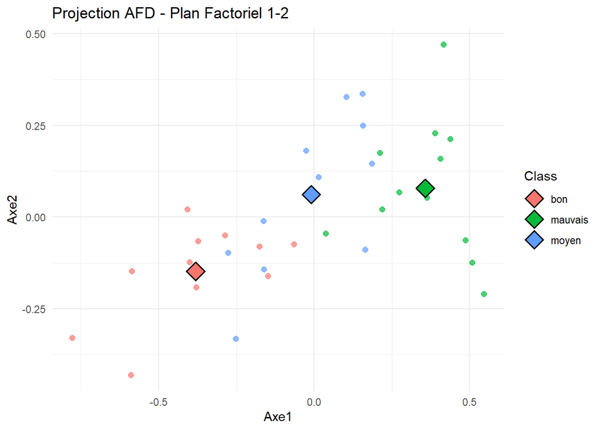

```r
# Affichage du graphique pour les vins
AFD_graph1(Scores_df)
```

#### 3.4 Inférence statistique

Nous effectuons un test de Wilks. En analyse factorielle discriminante, il s’agit de tester successivement le caractère discriminant des axes vis à vis des différentes classes.

Pour y parvenir, nous calculons les corrélations canoniques de chaque axe. Soit $\rho$, la valeur propre associée à chaque axe, la corrélation canonique est :

$${\eta ^2} = \frac{\rho }{{1 + \rho
}}$$

les corrélations canoniques des deux premiers axes sont:

```r
# Calcul des corrélations canoniques
# Elles représentent la part de variance expliquée par le groupe sur chaque axe canonique
Can_Corr <- Eigen_Values / (1 + Eigen_Values)

Can_Corr[1:2]
```

```
## [1] 0.7662929 0.1217084
```

Dans ce TD, nous allons simplifier les hypothèses. Sous Ho, nous posons que les corrélations canoniques des axes factoriels retenus sont égales à zero *versus* H1: au moins une des corrélations différent.

Le test est le suivant:

$$\left\{ \begin{array}{l}
{H_0}:\eta _{{\rm{axe 1}}}^2 = \eta _{{\rm{axe 2}}}^2 = 0\\
{H_1}:{\rm{ }}\eta _{{\rm{axe 1}}}^2{\rm{ et / ou }}\eta _{{\rm{axe
2}}}^2 \ne 0
\end{array} \right.$$

Nous calculons la quantité de Wilks $Wilks = {\Lambda _i} = \prod\limits_{i = 1}^2 {(1 - \lambda _i^2)}$

- rmq : Pour la calculer, on utilisera la fonction *cumsum()*

La quantité suivante suit une distribution de Chi-deux

$$- \left( {n - 1 - \frac{{p + k}}{2}}
\right)\log (\Lambda ) \to \chi _{p(k - 1)ddl}^2$$

avec:

- n: le nombre total d’observations
- p: le nombre de variables
- k: le nombre de classes

Pour les deux premiers axes retenus *(axe_selected = 2)*, L’ensemble des résultats de l’ADF sont résumés dans le tableau :

```r
# Paramètres
N <- nrow(X)
P <- ncol(X)
K <- nlevels(Y)
nb_axes <- 2

# Calcul du Lambda de Wilks
Lambda_Wilks <- exp(rev(cumsum(rev(log(1 - Can_Corr)))))
Wilks_Selected <- Lambda_Wilks[1:nb_axes]

# Statistique du test
Bartlett_Coeff <- -(N - 1 - (P + K)/2)
Chi2_Stat <- Bartlett_Coeff * log(Wilks_Selected)

# Degrés de liberté
axes_indices <- 1:nb_axes
DDL <- (P - axes_indices + 1) * (K - axes_indices)

# Probabilité
P_value <- 1 - pchisq(Chi2_Stat, df = DDL)

# Tableau récapitulatif
resultats_test <- data.frame(
  Axe = axes_indices,
  Wilks = Wilks_Selected,
  Stat_Test = Chi2_Stat,
  DDL = DDL,
  P_value = P_value
)

kable(resultats_test, caption = "Test de significativité des axes discriminants") %>%
  kable_styling(full_width = F)
```

Test de significativité des axes discriminants

| Axe | Wilks | Stat_Test | DDL | P_value |
| --- | --- | --- | --- | --- |
| 1 | 0.2052630 | 46.71217 | 8 | 0.0000002 |
| 2 | 0.8782916 | 3.82841 | 3 | 0.2805988 |

### 4. Encapsulation du code

Pour rappel, l’AFD est une méthode de classification supervisée. Le présent TD nous a permis de développer des scripts permettant:

- De calculer les axes factoriels relatives aux projections du compromis B/W
- De positionner les individus dans le plan factoriel ce qui permet de visualiser les positions des individus et des groupes les uns par rapport aux autres
- De tester la qualité de la projection et de la discrimination des groupes sur les axes factoriels

Le prochain TD aura pour objectif d’utiliser les coordonnées des observations dans le plan factoriel pour réaliser un classifieur supervisée dont nous testerons la qualité à l’aide d’une matrice des confusions.

Remarque : En cas de *non* discrimination des classes par les axes factoriels (acceptation de Ho et rejet de H1), il est évident qu’il n’est pas possible d’utiliser les projections des individus sur les axes factoriels pour réaliser un classifieur. Dans ce cas, la classification supervisée n’est pas réalisable par cette méthode

Nous créons une fonction générique que nous nommons *AFD*. Les arguments de la fonction sont les suivants :

- AFD <- function(X,Y,SS_tot, SS_intra, SS_inter, nb_axes = 2)
  - X et Y sont respectivement les variables prédictives et Y la variable à prédire
  - SS_tot, SS_intra, SS_inter sont les sommes des carrés calculées à partir de la fonction *MANOVA* que vous avez développée
  - nb_axes est le nombre d’axes sélectionné pour réaliser les projections. Par défaut, il est égal à 2 (projection dans un plan)

Cette fonction retourne une liste dont les éléments sont les suivants (sous forme de data frame):

- les vecteurs propres normalisés (appelés aussi *loading factors* en anglais)
- les valeur propres
- les scores
- le tableau des résultats du test de Wilks

Le data frame des Scores calculés à partir da la fonction *AFD* corresppondent à l’argument de la fonction *AFD_graph1*

Le script final (avec les résultats) doit être le suivant :

```r
# Fonction générique AFD
# Arguments :
# X, Y : Données
# SS_tot, SS_intra, SS_inter : Matrices d'inertie (issues de MANOVA)
# nb_axes : Nombre d'axes à retenir
AFD <- function(X, Y, SS_tot, SS_intra, SS_inter, nb_axes = 2) {

  # Préparation des données
  X <- as.matrix(X)
  Y <- as.factor(Y)
  N <- nrow(X)
  P <- ncol(X)
  K <- nlevels(Y)

  # Diagonalisation
  Mat_Ratio <- SS_inter %*% solve(SS_intra)
  res_eigen <- eigen(Mat_Ratio)

  # Vecteurs propres
  U <- Re(res_eigen$vectors)

  # Valeurs propres
  Eigen_Values <- Re(res_eigen$values)
  Eigen_Values[Eigen_Values < 1e-7] <- 0

  # Normalisation des vecteurs propres
  denom <- sqrt(diag(t(U) %*% SS_intra %*% U))
  U_Norm <- scale(U, center = FALSE, scale = denom)

  # Calcul des Scores
  Z <- scale(X, center = TRUE, scale = FALSE)
  Scores_All <- Z %*% U_Norm

  # Création du DataFrame de sortie
  Scores_df <- data.frame(Scores_All[, 1:nb_axes])
  colnames(Scores_df) <- paste0("Axe", 1:nb_axes)
  Scores_df$Class <- Y

  # Inférence Statistique
  Can_Corr <- Eigen_Values / (1 + Eigen_Values)
  Lambda_Wilks <- exp(rev(cumsum(rev(log(1 - Can_Corr)))))
  Wilks_Selected <- Lambda_Wilks[1:nb_axes]

  # Statistique et P-value
  Bartlett_Coeff <- -(N - 1 - (P + K)/2)
  Chi2_Stat <- Bartlett_Coeff * log(Wilks_Selected)

  axes_indices <- 1:nb_axes
  DDL <- (P - axes_indices + 1) * (K - axes_indices)
  P_value <- 1 - pchisq(Chi2_Stat, df = DDL)

  Test_Wilks <- data.frame(
    Axe = axes_indices,
    Wilks = Wilks_Selected,
    Stat_Test = Chi2_Stat,
    DDL = DDL,
    P_value = P_value
  )

  # Retour de la liste
  return(list(
    U_Norm = U_Norm,
    Eigen_Values = Eigen_Values,
    Scores = Scores_df,
    Test_Wilks = Test_Wilks,
    U = U
  ))
}
```

```r
# Test de la fonction sur les données Vins
res_afd_vin <- AFD(X, Y, res_manova$SS_tot, res_manova$SS_Intra, res_manova$SS_Inter)

# Affichage des résultats du test
kable(res_afd_vin$Test_Wilks, caption = "Résultats AFD Vins") %>% kable_styling(full_width = F)
```

Résultats AFD Vins

| Axe | Wilks | Stat_Test | DDL | P_value |
| --- | --- | --- | --- | --- |
| 1 | 0.2052630 | 46.71217 | 8 | 0.0000002 |
| 2 | 0.8782916 | 3.82841 | 3 | 0.2805988 |

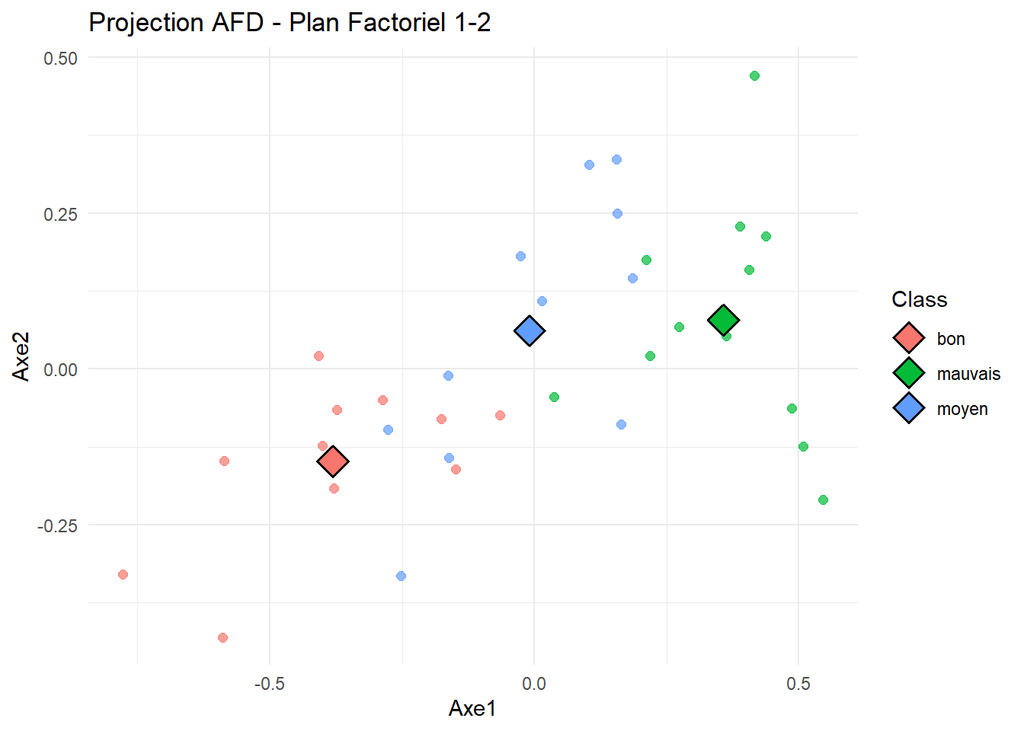

```r
# Affichage graphique
AFD_graph1(res_afd_vin$Scores)
```

### 5. Application

Pour valider votre fonction, vous utiliserez le fichier iris fourni par défaut en R.

Les résultats sont les suivants :

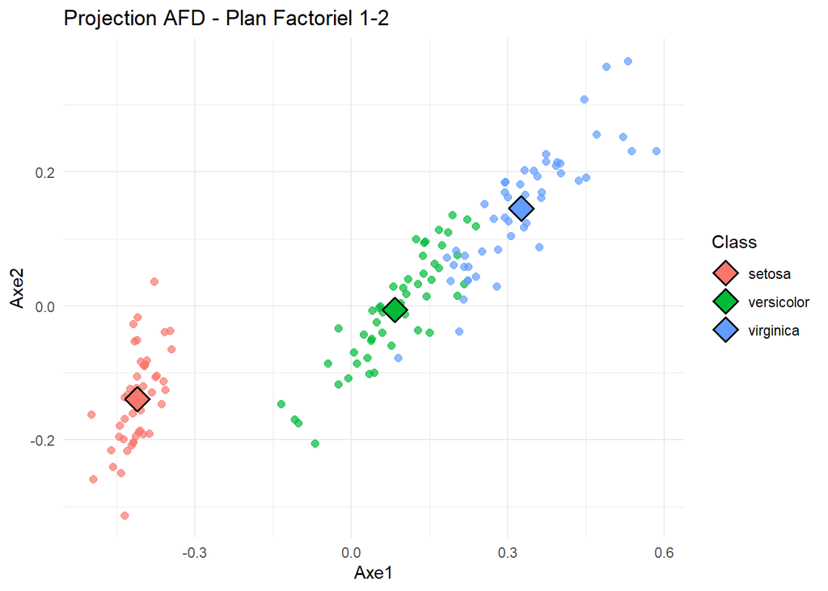

```r
# Chargement des données Iris
data(iris)
X_iris <- iris[, 1:4]
Y_iris <- iris$Species

# Calcul des inerties via MANOVA
res_manova_iris <- MANOVA(X_iris, Y_iris)

# Exécution de la fonction AFD
res_afd_iris <- AFD(X_iris, Y_iris,
                    res_manova_iris$SS_tot,
                    res_manova_iris$SS_Intra,
                    res_manova_iris$SS_Inter)

# Visualisation
AFD_graph1(res_afd_iris$Scores)
```

- Matrice des vecteurs propres normalisées

```r
print("Aperçu des vecteurs propres normalisés (Iris) :")
```

```
## [1] "Aperçu des vecteurs propres normalisés (Iris) :"
```

```r
print(head(res_afd_iris$U_Norm))
```

```
##             [,1]       [,2]         [,3]         [,4]
## [1,]  0.05046534 0.06663183  0.107295743  0.107295743
## [2,] -0.01780390 0.12217656  0.027831184  0.027831184
## [3,]  0.13381272 0.03005367  0.062069412  0.062069412
## [4,]  0.05706685 0.06283138 -0.001755236 -0.001755236
```

- Vecteurs propres

```r
print("Aperçu des vecteurs propres bruts (Iris) :")
```

```
## [1] "Aperçu des vecteurs propres bruts (Iris) :"
```

```r
print(head(res_afd_iris$U))
```

```
##            [,1]      [,2]        [,3]        [,4]
## [1,]  0.3255747 0.4281671  0.71896439  0.71896439
## [2,] -0.1148610 0.7850901  0.18649044  0.18649044
## [3,]  0.8632863 0.1931208  0.41591303  0.41591303
## [4,]  0.3681640 0.4037460 -0.01176144 -0.01176144
```

- Scores

```r
print("Aperçu des scores des individus (Iris) :")
```

```
## [1] "Aperçu des scores des individus (Iris) :"
```

```r
kable(head(res_afd_iris$Scores)) %>% kable_styling(full_width = F)
```

| Axe1 | Axe2 | Class |
| --- | --- | --- |
| -0.4179530 | -0.1291022 | setosa |
| -0.4191441 | -0.2035169 | setosa |
| -0.4461792 | -0.1954133 | setosa |
| -0.4226828 | -0.2082834 | setosa |
| -0.4247799 | -0.1235477 | setosa |
| -0.3583777 | -0.0386597 | setosa |

- Tests MANOVA axes factoriels

```r
kable(res_afd_iris$Test_Wilks, caption = "Test de Wilks (Iris)") %>% kable_styling(full_width = F)
```

Test de Wilks (Iris)

| Axe | Wilks | Stat_Test | DDL | P_value |
| --- | --- | --- | --- | --- |
| 1 | 0.0234386 | 546.11530 | 8 | 0e+00 |
| 2 | 0.7779734 | 36.52966 | 3 | 1e-07 |